# Anàlisi de la cohort de STAD utilitzant informació de MCN

## Preparació de les dades per a l’anàlisi

El fitxer de dades amb informació de l’estat WGD (Bielski) conté 223 casos de la cohort de STAD.

Tenim 407 fitxers de recomptes de la cohort de STAD.

L’anàlisi inclourà 184 mostres, 109 mostres sense WGD i 75 mostres amb WGD. Un 41% de les mostres de l’anàlisi han patit WGD.

## Pre-processament de les dades

Per a la filtració s’ha utilitzat un llindar de CPM de 0.08 i s’han filtrat 35600 gens, és a dir un 59% dels gens que teníem inicialment.

El rang de valors dels factors de normalització és de 0.6709055, 1.4245471.

## Exploració de les dades

### Gràfics de densitat

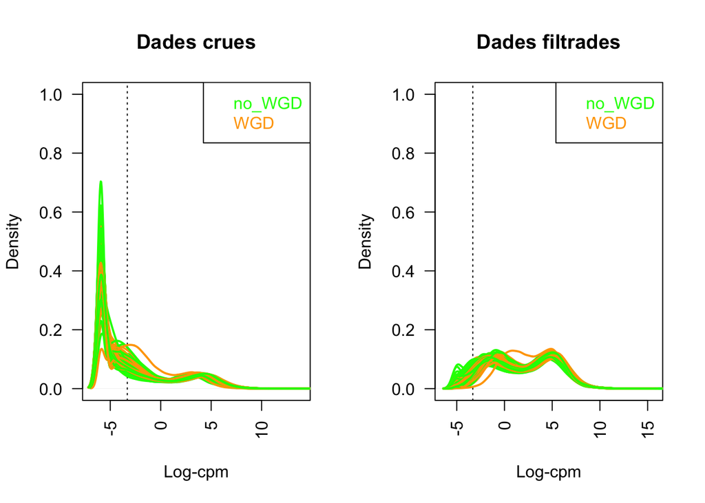

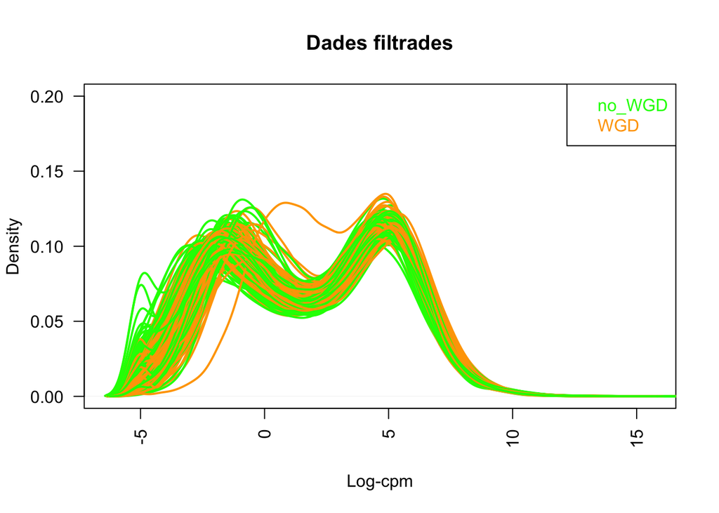

### Gràfic d’escalat multidimensional

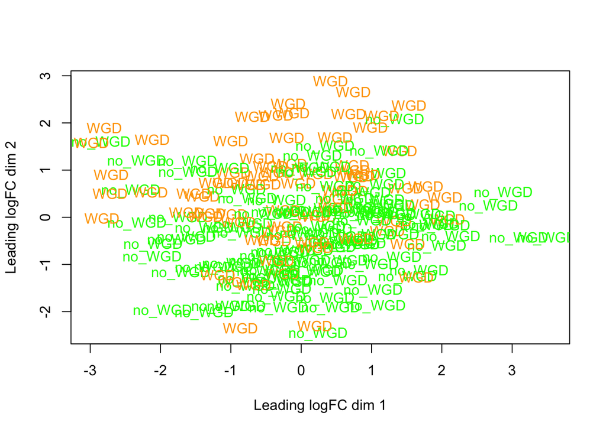

### Heatmap del gens més variables

Matriu de distàncies dels logCPM dels gens més variables. En aquest cas extraiem els 500 gens més variables a partir de les dades filtrades i normalitzades.

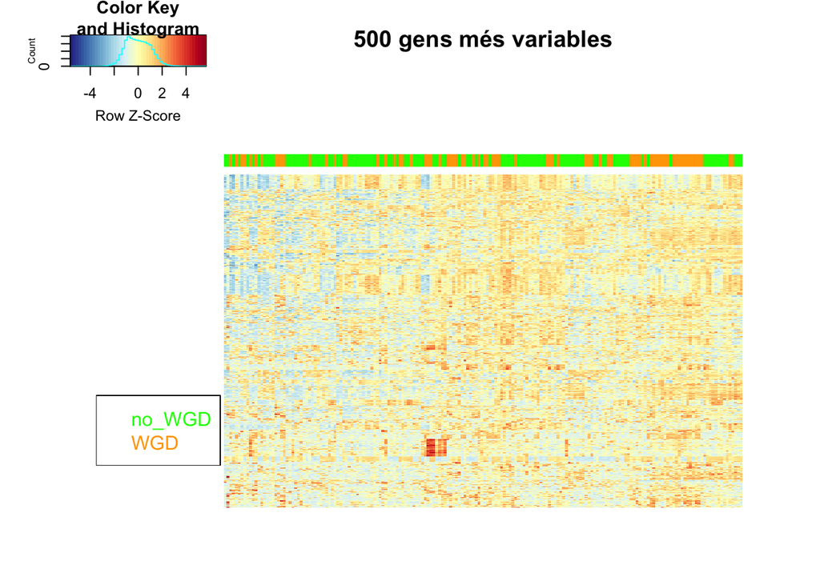

## Resultats de l’anàlisi d’expressió diferencial

### Nombre de gens diferencialment expressats

Contrastos amb p-valor ajustat (FDR) inferior a 0.05:

```
##        WGDvsNoWGD
## Down         2295
## NotSig      19566
## Up           3022
```

Contrastos amb p-valor sense ajustar inferior a 0.05 i valor absolut de log2-fold-change superior a 0.5 , aproximadament equivalent a un fold-change de 0.7 i 1.4:

```
##        WGDvsNoWGD
## Down         1059
## NotSig      21534
## Up           2290
```

### Llista de gens ordenats per significació

```
##       ensembl_gene_id hgnc_symbol      logFC      P.Value    adj.P.Val
## 5156  ENSG00000124228       DDX27  0.6827286 1.756097e-14 4.369695e-10
## 3462  ENSG00000109332      UBE2D3 -0.4316618 4.382210e-14 5.452127e-10
## 10427 ENSG00000164329       TENT2 -0.4701767 5.401475e-13 4.480164e-09
## 438   ENSG00000026103         FAS -1.1657427 1.981036e-12 9.858825e-09
## 559   ENSG00000041880       PARP3 -0.7825256 1.648334e-12 9.858825e-09
## 5749  ENSG00000129625       REEP5 -0.5168151 2.897180e-12 1.201509e-08
## 16396 ENSG00000213742  ZNF337-AS1  0.9607291 4.616195e-12 1.435810e-08
## 23779 ENSG00000273374              1.3621228 4.575498e-12 1.435810e-08
## 5879  ENSG00000130699        TAF4  0.6034149 5.641621e-12 1.559783e-08
## 8114  ENSG00000145741        BTF3 -0.5834213 7.972224e-12 1.983728e-08
## 2374  ENSG00000101255       TRIB3  1.4283786 3.486066e-11 7.228649e-08
## 24737 ENSG00000280213   UCKL1-AS1  0.9779884 3.417066e-11 7.228649e-08
## 12114 ENSG00000172728       FUT10 -0.6451440 3.910471e-11 7.484943e-08
## 2408  ENSG00000101407        TTI1  0.5338265 5.258368e-11 9.345997e-08
## 6622  ENSG00000135637     CCDC142  0.6336784 5.865310e-11 9.422973e-08
## 18613 ENSG00000232874              1.7123050 6.059059e-11 9.422973e-08
## 10178 ENSG00000163584     RPL22L1 -1.3077253 6.569584e-11 9.615939e-08
## 2347  ENSG00000101158      NELFCD  0.6258816 8.643055e-11 1.194806e-07
## 3903  ENSG00000113048      MRPS27 -0.5316478 9.501416e-11 1.244335e-07
## 10325 ENSG00000164040      PGRMC2 -0.4429421 1.494877e-10 1.808534e-07
```

### Representació gràfica dels resultats

#### Gràfic mitjana-diferència

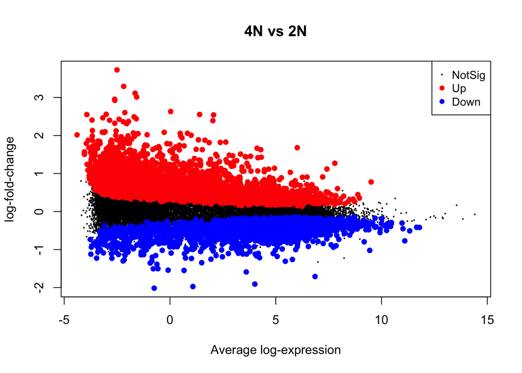

#### Gràfic de volcà

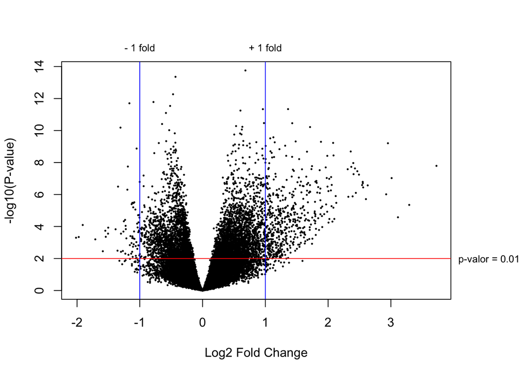

#### Heatmap dels gens més significatius

100 gens amb p-valor ajustat més baix:

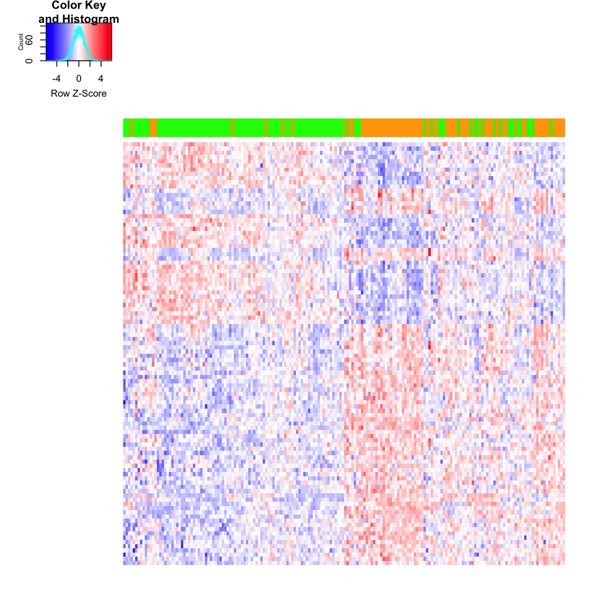

100 gens amb p-valor ajustat més baix després d’haver filtrat per aquells gens amb un logFC en valor absolut superior a 0.5 (aproximadament equivalent a FC superior a 1.4 o inferior a 0.7):

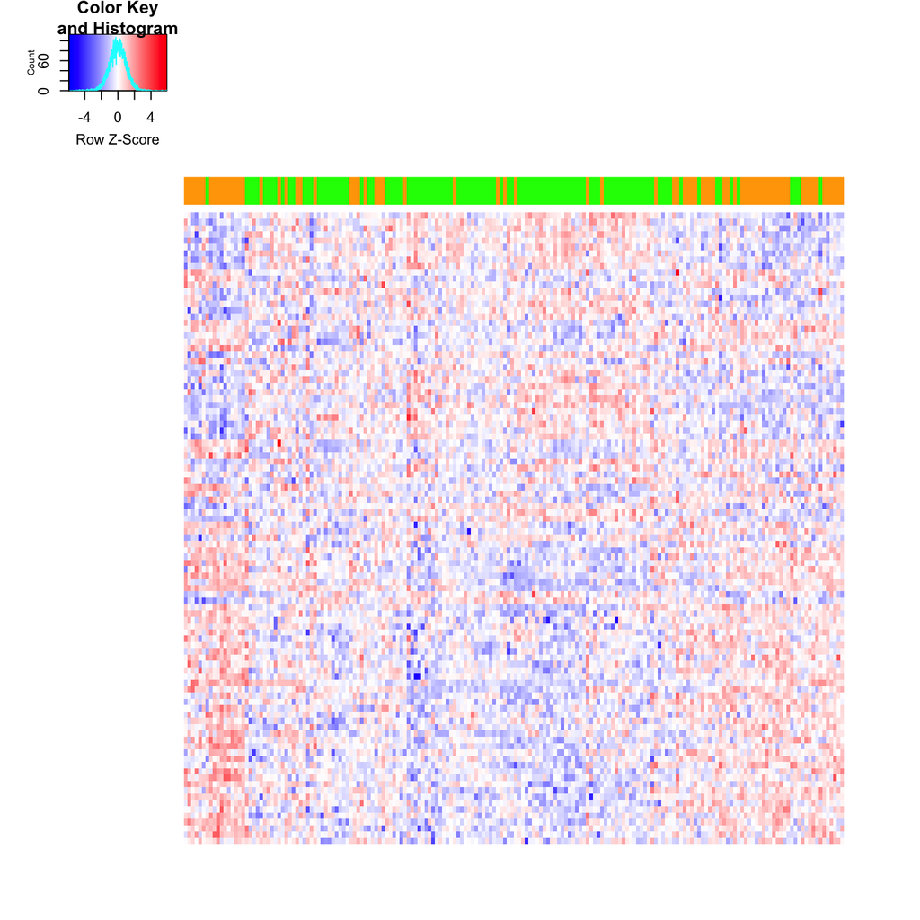

## Resultats de l’anàlisi d’enriquiment amb permutació de gene sets

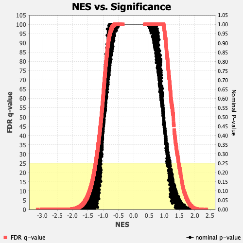

Termes enriquits al grup WGD

| NAME | FDR.q.val | NES |
| --- | --- | --- |
| GO_MEIOTIC_CELL_CYCLE_PROCESS | 0.0000000 | 2.379846 |
| GO_MEIOTIC_CHROMOSOME_SEGREGATION | 0.0000000 | 2.357808 |
| GO_MEIOTIC_CELL_CYCLE | 0.0004960 | 2.243733 |
| GO_HISTONE_EXCHANGE | 0.0004961 | 2.240193 |
| GO_CHROMATIN_ASSEMBLY | 0.0003968 | 2.227928 |
| GO_MEIOSIS_I_CELL_CYCLE_PROCESS | 0.0004128 | 2.220636 |
| GO_DNA_PACKAGING | 0.0004241 | 2.208409 |
| GO_NUCLEOSOME_ORGANIZATION | 0.0004949 | 2.179264 |
| GO_NUCLEAR_CHROMOSOME_SEGREGATION | 0.0009390 | 2.151101 |
| GO_CHROMOSOME_SEGREGATION | 0.0010951 | 2.139079 |
| GO_CHROMATIN_ASSEMBLY_OR_DISASSEMBLY | 0.0012229 | 2.126359 |
| GO_CHROMATIN_REMODELING_AT_CENTROMERE | 0.0012441 | 2.121171 |
| GO_CENTROMERE_COMPLEX_ASSEMBLY | 0.0013387 | 2.118956 |
| GO_SISTER_CHROMATID_SEGREGATION | 0.0013490 | 2.114724 |
| GO_DNA_CONFORMATION_CHANGE | 0.0013586 | 2.111066 |
| GO_DNA_REPLICATION_INITIATION | 0.0019920 | 2.091389 |
| GO_DNA_REPLICATION_INDEPENDENT_NUCLEOSOME_ORGANIZATION | 0.0022828 | 2.077803 |
| GO_SISTER_CHROMATID_COHESION | 0.0022113 | 2.075477 |
| GO_MEIOTIC_CHROMOSOME_SEPARATION | 0.0021994 | 2.072404 |
| GO_DNA_REPLICATION_DEPENDENT_NUCLEOSOME_ORGANIZATION | 0.0033585 | 2.043673 |

Termes enriquits al grup no_WGD

| NAME | FDR.q.val | NES |
| --- | --- | --- |
| GO_POSITIVE_REGULATION_OF_LEUKOCYTE_CELL_CELL_ADHESION | 0 | -3.147659 |
| GO_POSITIVE_REGULATION_OF_T_CELL_PROLIFERATION | 0 | -3.025808 |
| GO_LEUKOCYTE_PROLIFERATION | 0 | -3.021779 |
| GO_LEUKOCYTE_CELL_CELL_ADHESION | 0 | -3.019214 |
| GO_REGULATION_OF_T_CELL_ACTIVATION | 0 | -3.014031 |
| GO_POSITIVE_REGULATION_OF_CELL_ACTIVATION | 0 | -2.990787 |
| GO_T_CELL_ACTIVATION | 0 | -2.977778 |
| GO_POSITIVE_REGULATION_OF_INTERFERON_GAMMA_PRODUCTION | 0 | -2.970892 |
| GO_T_CELL_PROLIFERATION | 0 | -2.959643 |
| GO_REGULATION_OF_LEUKOCYTE_PROLIFERATION | 0 | -2.957053 |
| GO_POSITIVE_REGULATION_OF_LEUKOCYTE_PROLIFERATION | 0 | -2.941349 |
| GO_POSITIVE_REGULATION_OF_LEUKOCYTE_DIFFERENTIATION | 0 | -2.928962 |
| GO_IMMUNE_RESPONSE_REGULATING_CELL_SURFACE_RECEPTOR_SIGNALING_PATHWAY | 0 | -2.909973 |
| GO_REGULATION_OF_LYMPHOCYTE_ACTIVATION | 0 | -2.909091 |
| GO_GRANULOCYTE_MIGRATION | 0 | -2.893218 |
| GO_INTERFERON_GAMMA_PRODUCTION | 0 | -2.891279 |
| GO_MYELOID_LEUKOCYTE_MIGRATION | 0 | -2.869222 |
| GO_POSITIVE_REGULATION_OF_LYMPHOCYTE_DIFFERENTIATION | 0 | -2.865976 |
| GO_NEUTROPHIL_MIGRATION | 0 | -2.852546 |
| GO_LEUKOCYTE_CHEMOTAXIS | 0 | -2.833346 |

## Anàlisis d’immunitat

### ESTIMATE

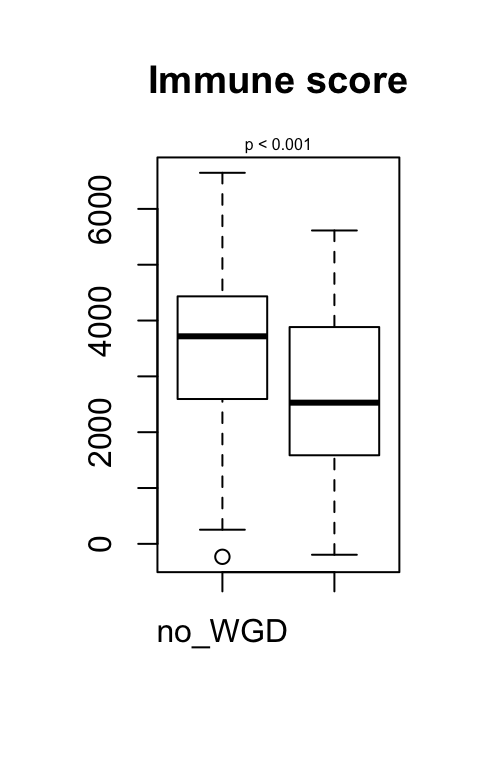

### Immunophenoscore

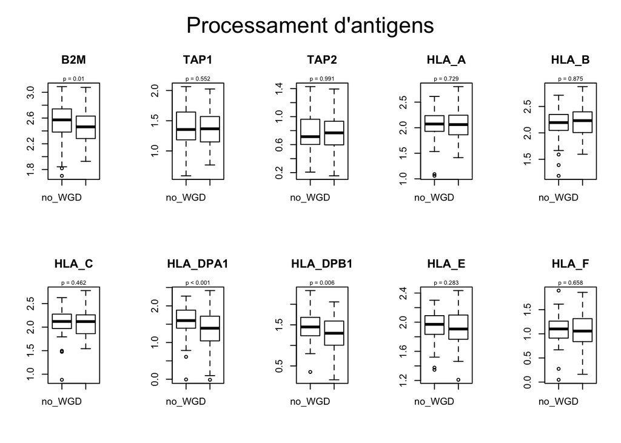

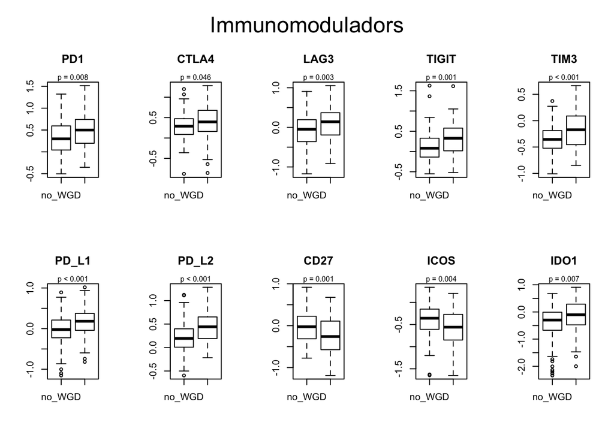

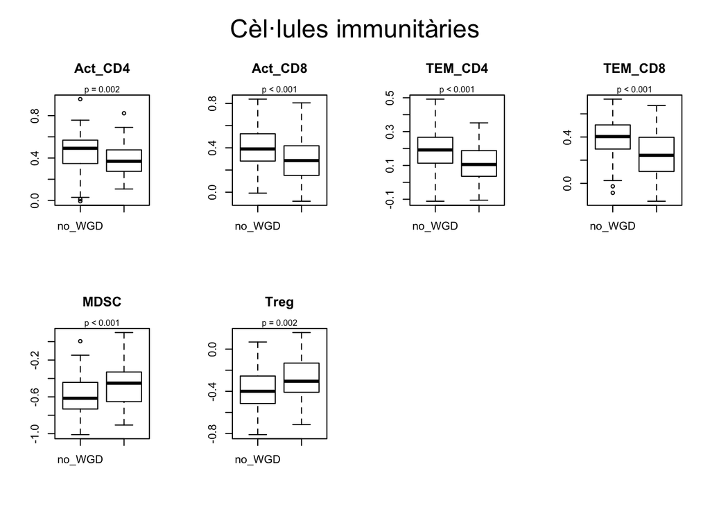

### Signatura 12-Chemokines

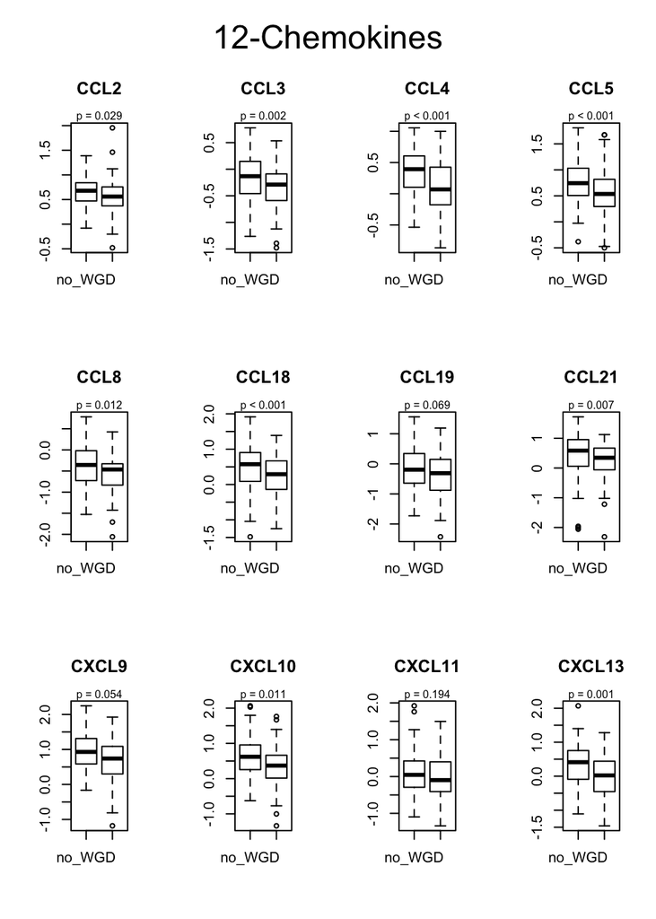